# Disentangling extrinsical and intrinsical factors influencing diabetic patient re-hospitalization

### An sneak-peek to the variance in the dataset

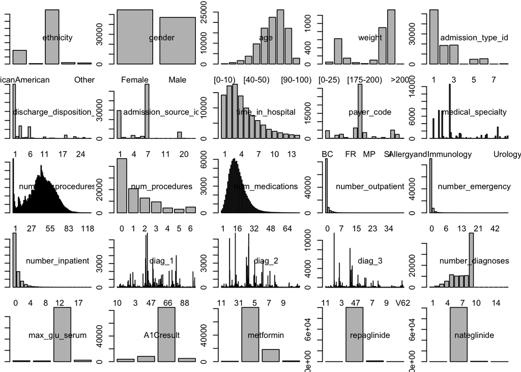

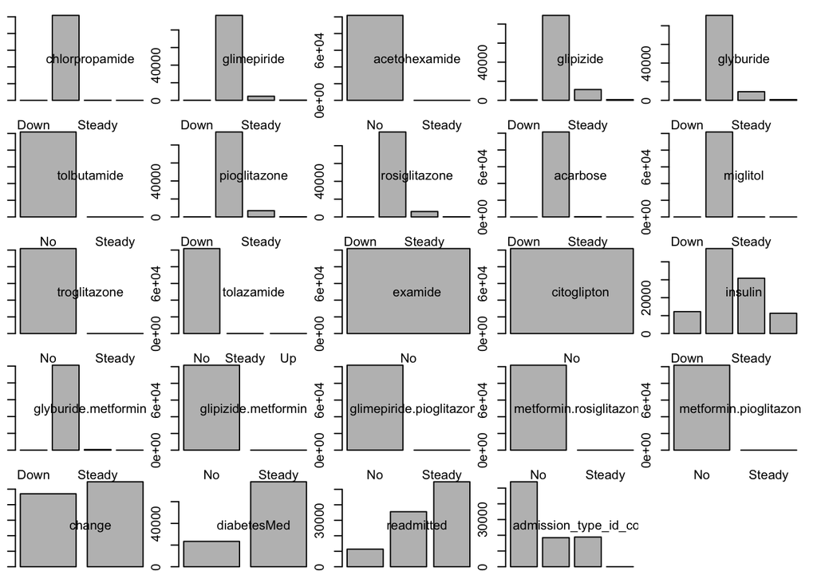

```r
## Lets now get an idea of the variance in the dataset by examining
# the distribution of individual variables

par(mfrow = c(5,5), mar = c(1,1,1,1))

# we avoid looping the id variables

for( i in 3:ncol(data_diabetes)){
  # if data is a factor, then make a bar-plot
  if(is.factor(data_diabetes[,i])){
    barplot(table(data_diabetes[,i]),
            main = "")
    legend("center",names(data_diabetes)[i], bty = "n")
  }
  # if data is numeric, plot a histogram
  if(is.numeric(data_diabetes[,i])){
    hist(data_diabetes[,i],
         breaks = 20,
         col = scales::alpha("red", 0.4),
         main = "")
    legend("center",names(data_diabetes)[i], bty = "n")

  }
}
```

```r
## This plots will be useful for later choices of variable transformation
# and variable inclusion in models. For now, lets explore if there are some
# underlying trends along the socio-demographic gradient of the dataset
```

### Exploring the socio-demographic distribution of medical encounters and average visits per in-patient

```r
# Individual patients in the dataset can have more than a single inpatient encounter,
# as such, we can rank patients by the number of in-visits and examine the variation
# of the sum of number of visits for the set of patients
# of various socio-demographic variable combinations

VisitsPerPatient <- aggregate(data_diabetes$encounter_id,
                              list(data_diabetes$patient_nbr,
                                   data_diabetes$gender,
                                   data_diabetes$age,
                                   data_diabetes$ethnicity),
                              length) # computes the sum of encounters per patient

names(VisitsPerPatient) <- c("patient_nbr", "gender","age",
                             "ethnicity","nVisits")

median(VisitsPerPatient$nVisits)
```

```
## [1] 1
```

```r
# half of all recorded patients have only been admitted once
```

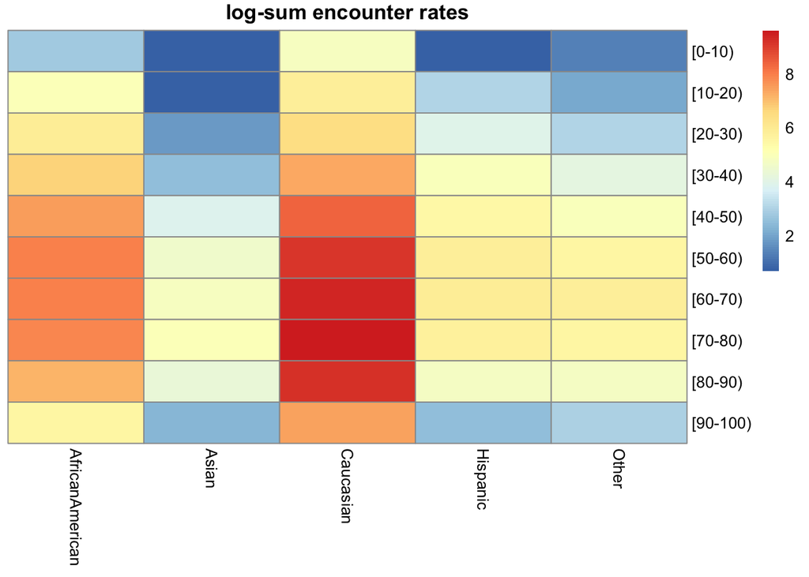

[figure not shown]

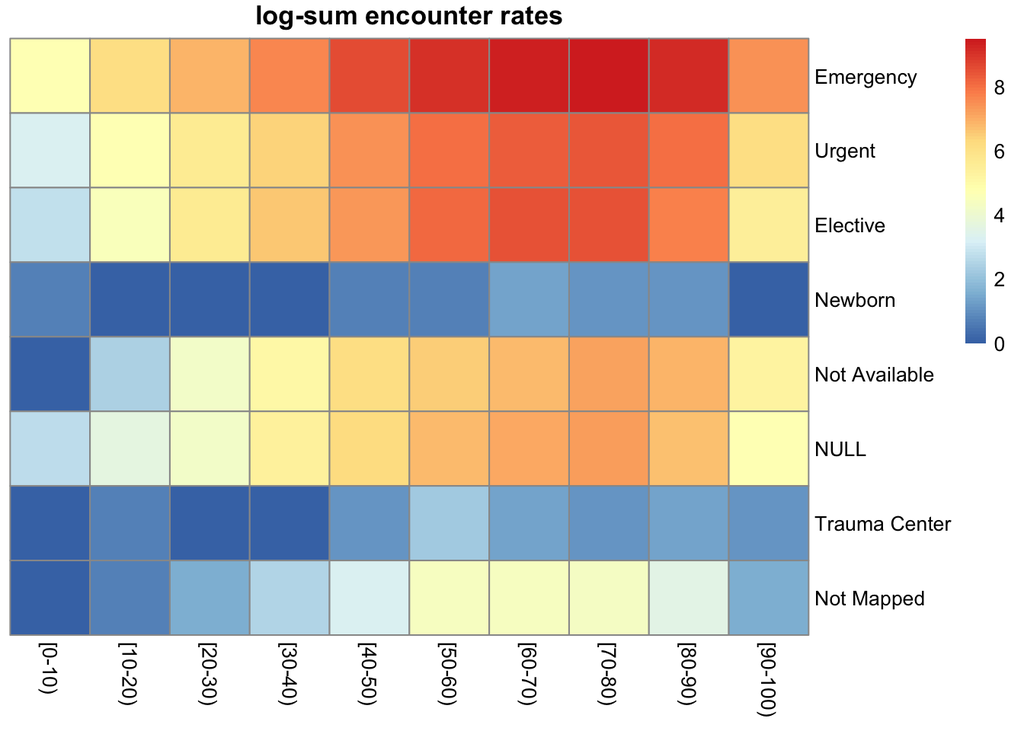

```r
# this code aggregates the previous dataset, to get an mean of the average patient visits, per socio-demo
# -graphic variable
MedVisPerPat <- aggregate(VisitsPerPatient$nVisits,
                          list(VisitsPerPatient$ethnicity,
                               VisitsPerPatient$age),
                          mean)
# give appropriate names to vars
names(MedVisPerPat) <- c("ethnicity", "age", "MnVp")

# how the mean number of visits are organized by age and ethnicity?
# we can visualize this trend with heat-maps

p1 <- pheatmap::pheatmap(log(xtabs(~age + ethnicity, VisitsPerPatient)),
                   cluster_rows = F,
                   cluster_cols = F,
                   main = "log-sum encounter rates")

p2 <-pheatmap::pheatmap((xtabs(MnVp~age + ethnicity, MedVisPerPat)),
                   cluster_rows = F,
                   cluster_cols = F,
                   main = "Mean visits per patient")


p1
p2
pheatmap::pheatmap(log1p(table(data_diabetes$admission_type_id,
                               data_diabetes$age)),
                   cluster_rows = F,
                   cluster_cols = F,
                   labels_row  = ID_type$description,
                   main = "log-sum encounter rates")
# we can see clearly that admittance is more prevalent between
# patients aged 50-90
# Most of patients are Caucasian descent, however the result is expected
# due to the demographic composition of the US. Further studies, however,
# could look into demographics curves for the same time period, and
# create null models to test whether any ethnicity is overepresented in
# in-patient diabetes data.


# Note that the change in admissions is represented in the heat-map as change in orders of magnitude.
```

### Exploring the distribution of hospitalization time in relation to admission type and socio-demographic variables

```r
# with this we can reorder the levels of weight factors for plotting purposes
data_diabetes$weight <- factor(data_diabetes$weight,levels(data_diabetes$weight)[c(1,6,7,8,2,3,4,5,9)])
# same with age
data_diabetes$age <- factor(data_diabetes$age,levels(data_diabetes$age)[10:1])

# How much varies the average time in hospital along the patient groups
data_diabetes$time_in_hospital <- as.numeric(data_diabetes$time_in_hospital)
```

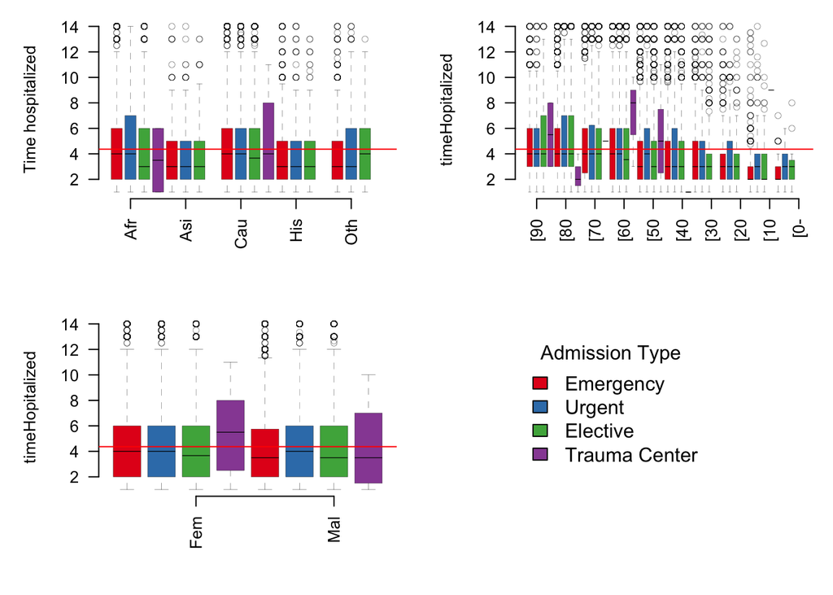

```r
## With this we calculate the average time hospitalized by patient
AvTimeInHosp <- aggregate(data_diabetes$time_in_hospital,
                          list(data_diabetes$patient_nbr,
                               data_diabetes$admission_type_id_corr,
                               data_diabetes$gender,
                               data_diabetes$age,
                               data_diabetes$ethnicity),
                          mean)

names(AvTimeInHosp) <- c("patient_nbr", "admission_type_id", "gender",
                         "age", "ethnicity","timeHopitalized")



## This code below plots the distribution of average hospitalization time along
# the socio-demographic variation as well as the variation on admission types

par(mfrow = c(2,2), las = 2, mar = c(5,5,1,1))
boxplot(timeHopitalized~admission_type_id+ ethnicity,
        col = rep(RColorBrewer::brewer.pal(
          length(unique(AvTimeInHosp$admission_type_id)),
          "Set1"),
          length(unique(AvTimeInHosp$ethnicity))),
        data = AvTimeInHosp,
        xaxt = "n",
        ylab = "Time hospitalized",
        xlab = "",
        frame = F, lwd = 0.2)
# makes a custom x-axis
axis(1, seq(2,18,length.out = 5),
     strtrim(unique(AvTimeInHosp$ethnicity),3))

# plot a reference line with the mean of all observations
abline(h = mean(AvTimeInHosp$timeHopitalized),
       col  = "red")

# plot the distribution of hospitalized time along age and admission type variables
boxplot(timeHopitalized~admission_type_id+ age,
        col = rep(RColorBrewer::brewer.pal(
          length(unique(AvTimeInHosp$admission_type_id)),
          "Set1"),
          length(unique(AvTimeInHosp$age))),
        AvTimeInHosp,
        xlab = "",
        xaxt = "n",
        frame = F, lwd = 0.2)
# makes a custom x-axis
axis(1, seq(2,40,length.out = 10),
     strtrim(unique(AvTimeInHosp$age),3)) # trims the length of variable names
# plot a reference line at the distributional mean
abline(h = mean(AvTimeInHosp$timeHopitalized),
       col  = "red")
# plots a box-plot relating average time hospitalized by admission type and gender
boxplot(timeHopitalized~admission_type_id+ gender,
        col = rep(RColorBrewer::brewer.pal(
          length(unique(AvTimeInHosp$admission_type_id)),
          "Set1"),
          length(unique(AvTimeInHosp$gender))),
        AvTimeInHosp,
        xlab = "",
        xaxt = "n",
        frame = F,
        lwd = 0.2)
# plots reference line
abline(h = mean(AvTimeInHosp$timeHopitalized),
       col  = "red")
# custom x-axis
axis(1, seq(3,7,length.out = 2),
     strtrim(unique(AvTimeInHosp$gender),3))

# plots the legend panel
plot(1,1,
     frame = F,
     pch  = "",
     axes = F,
     xlab = "",
     ylab = "")
legend("left" ,
       cex = 1.2,
       bty = "n",
       fill =  rep(RColorBrewer::brewer.pal(
         length(unique(AvTimeInHosp$admission_type_id)),
         "Set1"),
         length(unique(AvTimeInHosp$ethnicity))),
       title = "Admission Type",
       legend = ID_type$description[
         as.numeric(as.character(unique(AvTimeInHosp$admission_type_id)))])
```

### Prepping dataset for further modelling

```r
# we can prune the dataset eliminating those variables below the missing data threshold
data_diabetes_pr <- data_diabetes[,!names(data_diabetes)
                                  %in% missingInfo$var[missingInfo$miss_info >0.3]]

# admission type == 7, has few observations that can bias model estimates
# we can remove those from the dataset

table(data_diabetes_pr$admission_type_id_corr)
```

```
##
##     1     2     3     7
## 53990 18480 18869    21
```

```r
data_diabetes_pr <- data_diabetes_pr[-which(data_diabetes_pr$admission_type_id_corr == 7),]
```

### Fitting a logistic model to predict patient re-admittance

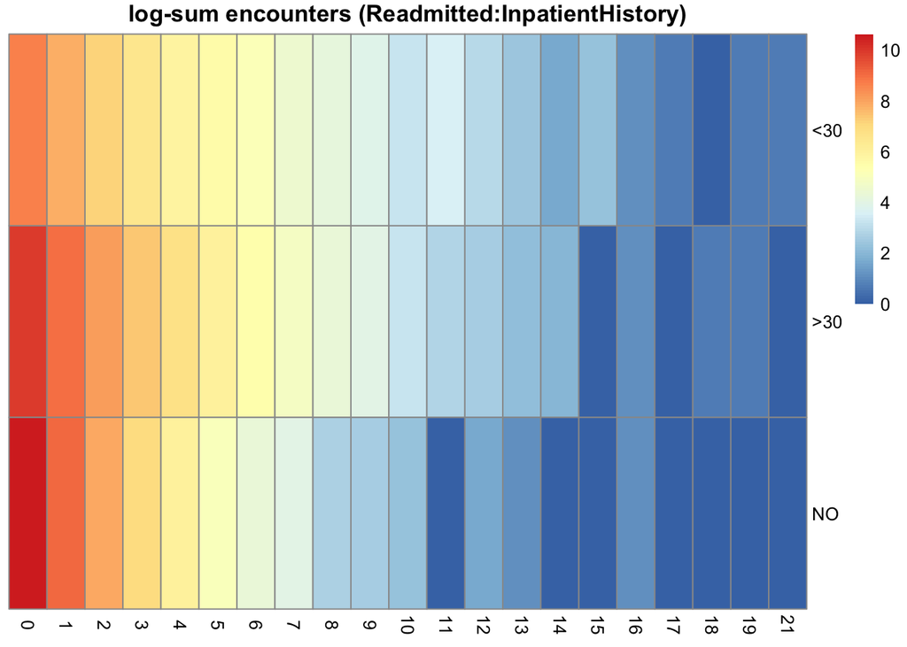

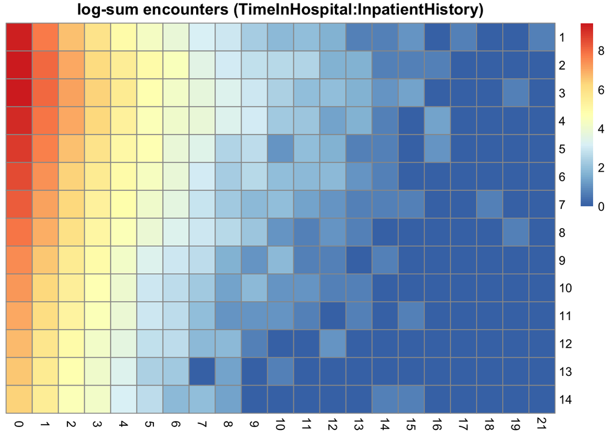

```r
# Can we predict whether an inpatient will be
# re-admitted after being discharged?


pheatmap::pheatmap(log1p(table(data_diabetes_pr$readmitted,
                               data_diabetes_pr$number_inpatient)),
                   cluster_rows = F,
                   cluster_cols = F,
                   main = "log-sum encounters (Readmitted:InpatientHistory)")



pheatmap::pheatmap(log1p(table(data_diabetes_pr$time_in_hospital,
                               data_diabetes_pr$number_inpatient)),
                   cluster_rows = F,
                   cluster_cols = F,
                   main = "log-sum encounters (TimeInHospital:InpatientHistory)")
```

#### Subsetting data to “first-addmittance” patients only

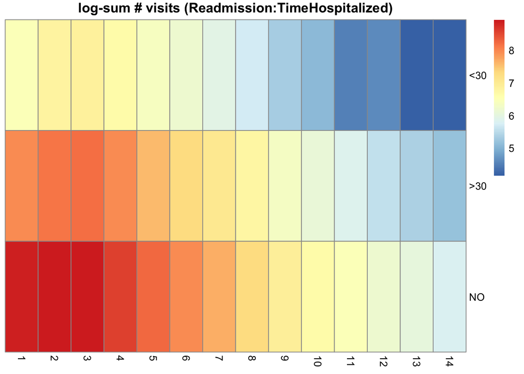

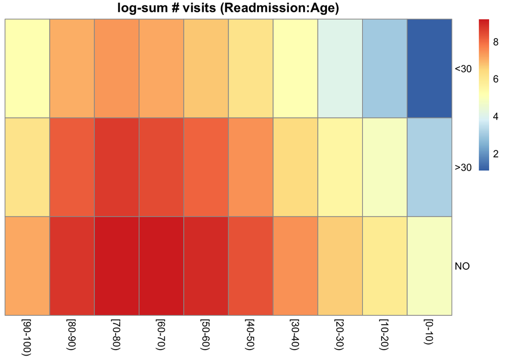

```r
# To do this, let's focus only on "first-visit" in-patients
data_diabetes_fr <- data_diabetes_pr[as.numeric(as.character(data_diabetes_pr$number_inpatient)) == 0,]

data_diabetes_fr$num_lab_procedures <- as.numeric(as.character(data_diabetes_fr$num_lab_procedures))
data_diabetes_fr$num_medications <- as.numeric(as.character(data_diabetes_fr$num_medications))
data_diabetes_fr$num_procedures <- as.numeric(as.character(data_diabetes_fr$num_procedures))
data_diabetes_fr$number_diagnoses <- as.numeric(as.character(data_diabetes_fr$number_diagnoses))
data_diabetes_fr$number_emergency <- as.numeric(as.character(data_diabetes_fr$number_emergency))
data_diabetes_fr$number_outpatient <- as.numeric(as.character(data_diabetes_fr$number_outpatient))




pheatmap::pheatmap(log1p(table(data_diabetes_fr$readmitted,
                               data_diabetes_fr$time_in_hospital)),
                   cluster_rows = F,
                   cluster_cols = F,
                   main = "log-sum # visits (Readmission:TimeHospitalized)")

pheatmap::pheatmap(log1p(table(data_diabetes_fr$readmitted,
                               data_diabetes_fr$age)),
                   cluster_rows = F,
                   cluster_cols = F,
                   main = "log-sum # visits (Readmission:Age)")
```

```r
# To simplify the analysis, we can reduce the variation of re-admittance to a binary response

data_diabetes_fr$readmited_ord <- ifelse(data_diabetes_fr$readmitted %in% c(">30","<30"), 1, 0)
```

#### Variable normalization

Normalization is applied to transform distinctly measured continuous variables into a standard scale to facilitate comparison of variable effects. Often, this normalization is achieved by setting all variables to a mean = 0 and sd = 1

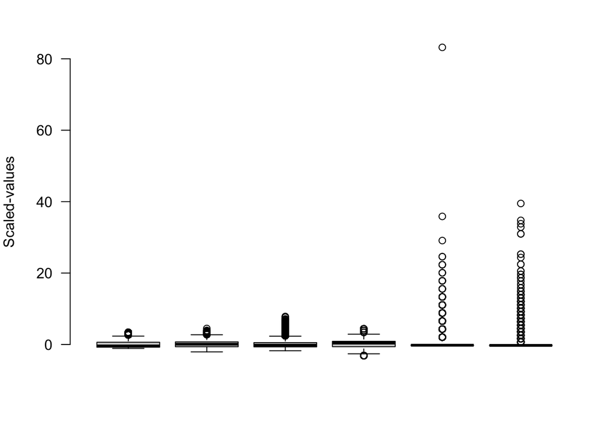

```r
# normalize variables and transform variables

par(mar = c(4,4,2,2))
boxplot(data.frame(scale(data_diabetes_fr$time_in_hospital),
                   scale(data_diabetes_fr$num_lab_procedures),
                   scale(data_diabetes_fr$num_medications),
                   scale(data_diabetes_fr$number_diagnoses),
                   scale((data_diabetes_fr$number_emergency)),
                   scale((data_diabetes_fr$number_outpatient))),
        las  = 2, frame = F,
        ylab = "Scaled-values",
          xaxt = "n")
```

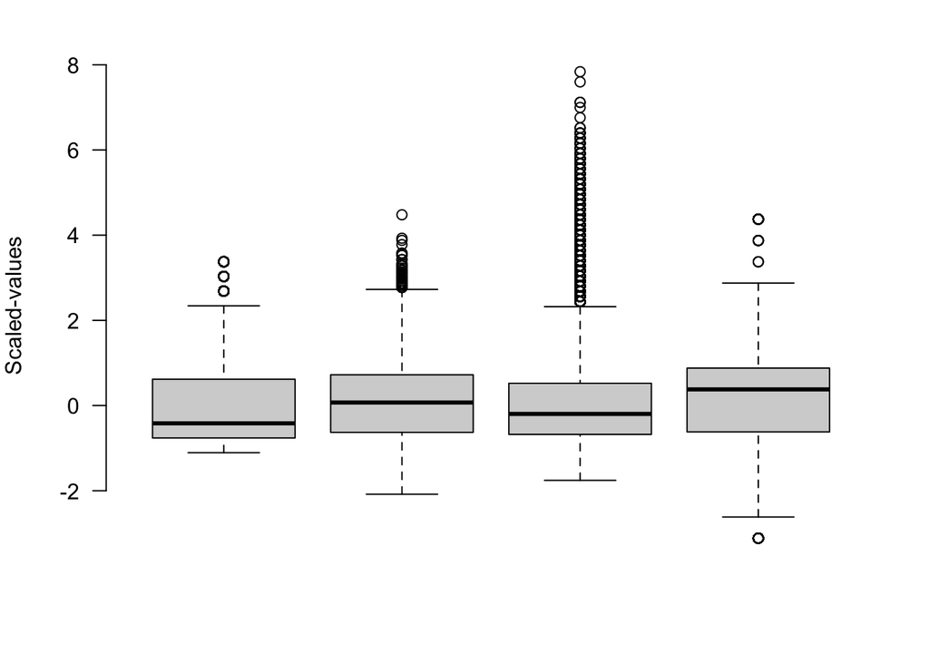

```r
## transform previous emergency and outpatient data as binary, to reduce outliers

data_diabetes_fr$emerg_n_bin <- ifelse(data_diabetes_fr$number_emergency>1,1,0)
data_diabetes_fr$outpat_n_bin<- ifelse(data_diabetes_fr$number_outpatient>1,1,0)

boxplot(data.frame(scale(data_diabetes_fr$time_in_hospital),
                   scale(data_diabetes_fr$num_lab_procedures),
                   scale(data_diabetes_fr$num_medications),
                   scale(data_diabetes_fr$number_diagnoses)),
        las  = 2, frame = F,
        ylab = "Scaled-values",
        xaxt = "n")
```

```r
# normalize the variation of numerical variables to a mean of 0 and variable sd, so the magnitude of
# effects can be comparable among variables

data_diabetes_fr$time_in_hospital <- scale(data_diabetes_fr$time_in_hospital)
data_diabetes_fr$num_lab_procedures <-scale(data_diabetes_fr$num_lab_procedures)
data_diabetes_fr$num_medications <- scale(data_diabetes_fr$num_medications)
data_diabetes_fr$number_diagnoses <- scale(data_diabetes_fr$number_diagnoses)
data_diabetes_fr$number_emergency <- scale(data_diabetes_fr$number_emergency)
```

#### Looking for redundant variables

We can examine which variables are closely correlated to avoid adding many redundant variables into our models. Redundant variables can be problematic, as they inflate predictor variance, increases model complexity, and can create overfitted models, that is, models that are not able to generalize their predictions into new data.

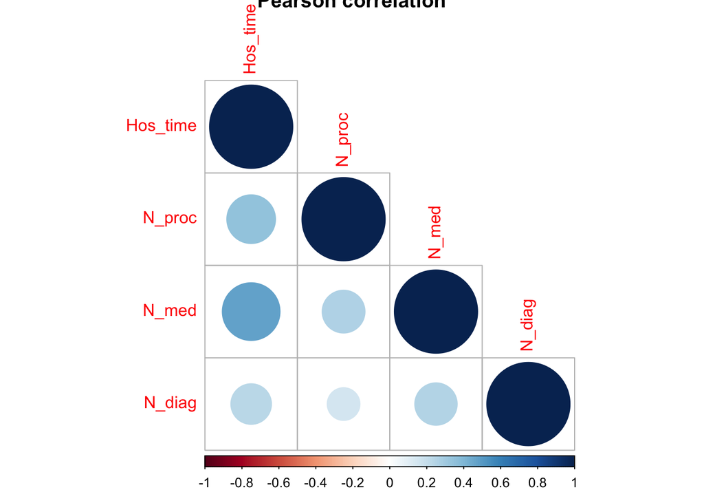

```r
# we can examine correlations among numerical variable pairs

toCorr <- cbind(
  "Hos_time" = scale(data_diabetes_fr$time_in_hospital),
  "N_proc" = scale(data_diabetes_fr$num_lab_procedures),
  "N_med" =scale(data_diabetes_fr$num_medications),
  "N_diag" = scale(data_diabetes_fr$number_diagnoses))

corrle <- Hmisc::rcorr(toCorr)
rownames(corrle$r) <- c("Hos_time", "N_proc", "N_med","N_diag")
colnames(corrle$r) <- c("Hos_time", "N_proc", "N_med", "N_diag")

corrplot::corrplot(corrle$r,
                   type = "lower", is.corr = T,
                   main = "Pearson correlation")
```

#### Fitting the logistic model

A logistic model is a model that allows to investigate the relationship between a set of predictor variables and a binary response variable (i.e. yes/no outcome). In this model, we will account for the potential underlying variation in the response data due to socio-demographic factors and lenght of hospitalization. We will do that by adding random effects to our model, which helps testing the influence of predictors accounting for the hierarchical grouping of observations in our dataset.

```r
# Subset data needed to fit a logistic model


data2model <- data_diabetes_fr[,-which(names(data_diabetes_fr) %in% c("encounter_id", "patient_nbr","admission_type_id",
                                                                      "discharge_disposition_id","diag_1","diag_2","diag_3",
                                                                      "number_inpatient", "number_outpatient","number_emergency",
                                                                      "readmitted", "sqrt_timeHospital"))]


# check which variables have less than 2 levels

apply(data2model, 2, function(x) length(unique(x)))
```

```
##                ethnicity                   gender                      age
##                        6                        3                       10
##      admission_source_id         time_in_hospital       num_lab_procedures
##                       17                       14                      116
##           num_procedures          num_medications         number_diagnoses
##                        7                       75                       16
##            max_glu_serum                A1Cresult                metformin
##                        4                        4                        4
##              repaglinide              nateglinide           chlorpropamide
##                        4                        4                        4
##              glimepiride            acetohexamide                glipizide
##                        4                        2                        4
##                glyburide              tolbutamide             pioglitazone
##                        4                        2                        4
##            rosiglitazone                 acarbose                 miglitol
##                        4                        3                        3
##             troglitazone               tolazamide                  examide
##                        2                        2                        1
##              citoglipton                  insulin      glyburide.metformin
##                        1                        4                        4
##      glipizide.metformin glimepiride.pioglitazone  metformin.rosiglitazone
##                        2                        1                        2
##   metformin.pioglitazone                   change              diabetesMed
##                        2                        2                        2
##   admission_type_id_corr            readmited_ord              emerg_n_bin
##                        4                        2                        2
##             outpat_n_bin
##                        2
```

```r
# arrange variable levels

data2model$A1Cresult <- factor(data2model$A1Cresult,levels(data2model$A1Cresult)[c(4,1,2,3)])
data2model$insulin <- factor(data2model$insulin, levels(data2model$insulin)[c(2,1,3,4)])
data2model$change <- factor(data2model$change, levels(data2model$change)[c(2,1)])
data2model$max_glu_serum <- factor(data2model$max_glu_serum, levels(data2model$max_glu_serum)[c(4,3,1,2)])
```

```r
library(lme4)
# fit a logistic model to investigate the factors leading to increasing probability of re-admittance,
# controlling for socio-demographic variation and time of stay in the hospital
data2model <- droplevels(data2model)
data2model <- data2model[complete.cases(data2model),]
# fit a suite of models

## First, try a model that feeds on operational data

mod_ext <- lme4::glmer(readmited_ord~
                      admission_type_id_corr+
                      as.factor(emerg_n_bin)+
                      as.factor(outpat_n_bin)+
                      (1|time_in_hospital) +
                        (1|ethnicity/gender/age),
                    data = data2model,
                    family = binomial(link = "logit"),
                    control = glmerControl(optimizer ="bobyqa"))
```

```
## boundary (singular) fit: see ?isSingular
```

```r
## Second, try a model that feeds on medical data

mod_med <- lme4::glmer(readmited_ord~
                         max_glu_serum+
                         number_diagnoses+
                         num_medications+
                         A1Cresult+
                         insulin+
                         change+
                         diabetesMed+
                         (1|time_in_hospital) +
                           (1|ethnicity/gender/age),
                       data = data2model,
                       family = binomial(link = "logit"),
                       control = glmerControl(optimizer ="bobyqa"))
```

```
## boundary (singular) fit: see ?isSingular
```

```r
## Third, try a model that feeds on both operational and medical data

mod_mix <- lme4::glmer(readmited_ord~
                         A1Cresult+
                         max_glu_serum+
                         insulin+
                         change+
                         diabetesMed+
                      admission_type_id_corr+
                      as.factor(emerg_n_bin)+
                      as.factor(outpat_n_bin)+
                         (1|time_in_hospital) +
                        number_diagnoses+
                         num_medications+
                         (1|ethnicity/gender/age),
                       data = data2model,
                       family = binomial(link = "logit"),
                       control = glmerControl(optimizer ="bobyqa"))
```

```
## boundary (singular) fit: see ?isSingular
```

#### Model selection

With model selection we select the “best-fit” model from a pool of candidate models that test distinct variable combinations to explain the variation of a response variable. Although, there are several ways to select for the best-fit model, in this analysis we will do it through AIC (Akaike Information Criterion), which is a measure of model “quality” based on a compromise between model complexity and the model fit. Greater relative AIC values often indicate “poor” model quality.

```r
# lets compare the models and find the best-fit model with AIC

AICcmodavg::aictab(list(mod_ext, mod_med, mod_mix),
                   modnames = c("External", "Medical", "Mix"))
```

|  | Modnames | K | AICc | Delta_AICc | ModelLik | AICcWt | LL | Cum.Wt |
| --- | --- | --- | --- | --- | --- | --- | --- | --- |
| 3 | Mix | 22 | 76592.21 | 0.0000 | 1.000000e+00 | 1.000000e+00 | -38274.10 | 1 |
| 2 | Medical | 18 | 76900.62 | 308.4062 | 1.072598e-67 | 1.072598e-67 | -38432.30 | 1 |
| 1 | External | 9 | 77338.59 | 746.3818 | 8.419032e-163 | 8.419032e-163 | -38660.29 | 1 |

#### Evaluating model(s) performance(s)

```r
library(pROC)
```

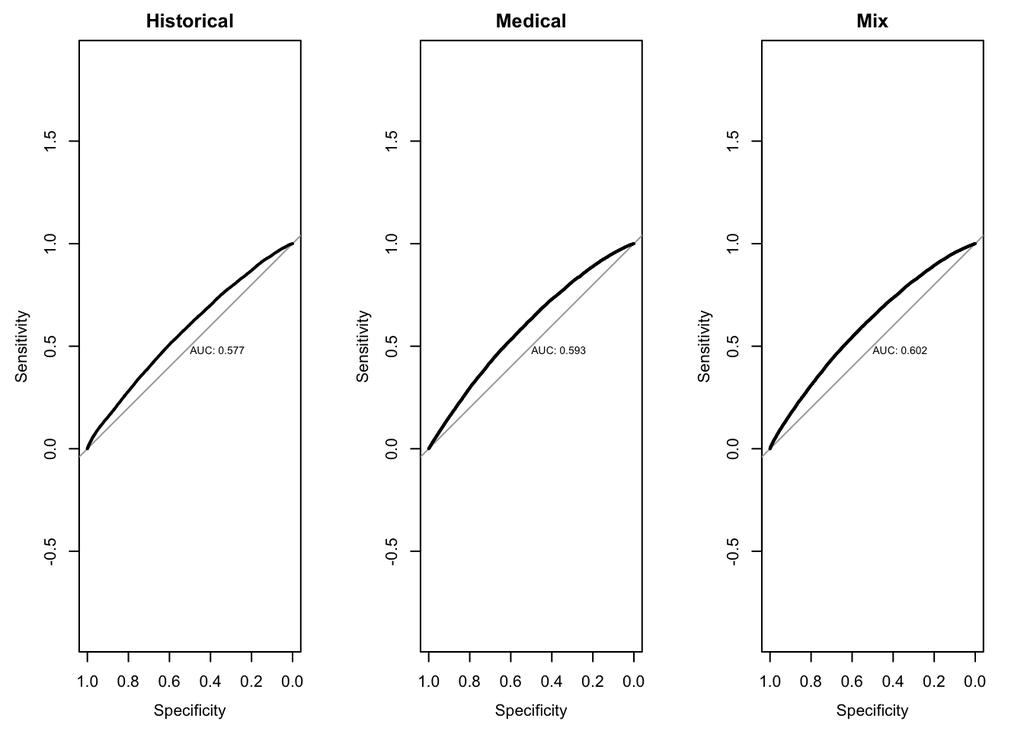

```r
# build a receiver operator curve for both models
pred1 <-predict(mod_ext,data2model, type = "response", allow.new.levels = T)
pred2<-  predict(mod_med,data2model, type = "response", allow.new.levels = T)
pred3 <- predict(mod_mix,data2model, type = "response", allow.new.levels = T)

rocD <- roc(data2model$readmited_ord,pred1)
rocD1 <- roc(data2model$readmited_ord,pred2)
rocD2 <- roc(data2model$readmited_ord, pred3)
par(mfrow = c(1,3))
plot(rocD, print.auc = T, main = "Historical")
plot(rocD1, print.auc = T, main  = "Medical")
plot(rocD2, print.auc = T, main = "Mix")
```

#### Evaluatiing model assumptions

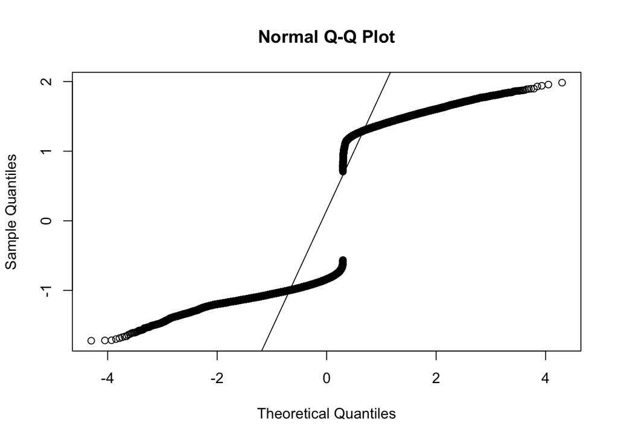

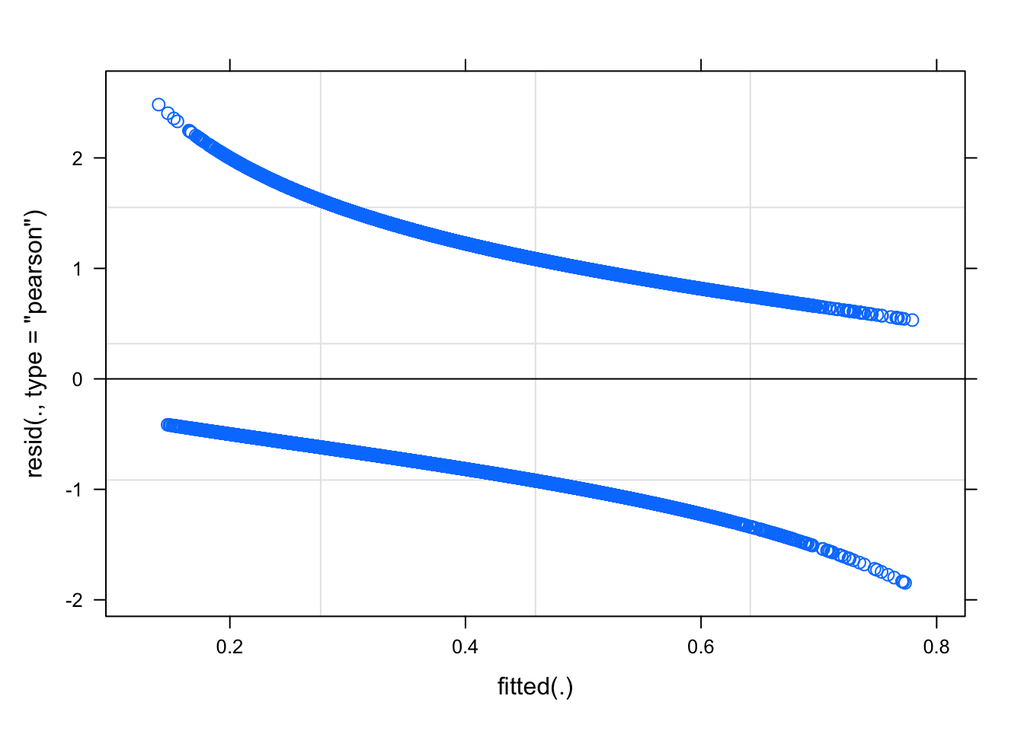

[figure not shown]

```r
qqnorm(resid(mod_mix))
qqline(resid(mod_mix))


plot(mod_mix)


# compute the variance of residuals among models

s1 <- sum(residuals(mod_med, type  = "pearson")^2)/(nrow(data2model)-length(lme4::fixef(mod_med)))

# compute the variance of residuals
s2 <- sum(residuals(mod_ext, type  = "pearson")^2)/(nrow(data2model)-length(lme4::fixef(mod_ext)))

# compute the variance of residuals
s3 <- sum(residuals(mod_mix, type  = "pearson")^2)/(nrow(data2model)-length(lme4::fixef(mod_mix)))


barplot(s1,s2,s3,
        xlab = " Models",
        ylab = "Variance of residuals")
```

#### Exploring model results

We need to observe the distribution of coefficients among variables to interpret the results of a logistic model. The model coefficients (“Effect estimates”) are a measure of change (in log-odds) of a variable outcome, in this case, the chances for re-admittance. Coefficients represent one unit of change in the log-odds of the response variable for each unit in the predictor variable, while holding all other variables constant.

The odd-ratios are closely related to the model coefficients. In fact, they correspond to the $e^c$ where $c$ represents the model coefficient value. The odd ratios represent a measure of the relationship between the predictor factor and the response variable. Odd ratios greater than one represent positive associations, whereas Odd rations below 1 represents negative associations.

```r
summary(mod_mix)
```

```
## Generalized linear mixed model fit by maximum likelihood (Laplace
##   Approximation) [glmerMod]
##  Family: binomial  ( logit )
## Formula: readmited_ord ~ A1Cresult + max_glu_serum + insulin + change +
##     diabetesMed + admission_type_id_corr + as.factor(emerg_n_bin) +
##     as.factor(outpat_n_bin) + (1 | time_in_hospital) + number_diagnoses +
##     num_medications + (1 | ethnicity/gender/age)
##    Data: data2model
## Control: glmerControl(optimizer = "bobyqa")
##
##      AIC      BIC   logLik deviance df.resid
##  76592.2  76789.8 -38274.1  76548.2    58754
##
## Scaled residuals:
##     Min      1Q  Median      3Q     Max
## -1.8464 -0.8029 -0.6490  1.1467  2.4830
##
## Random effects:
##  Groups                 Name        Variance  Std.Dev.
##  age:(gender:ethnicity) (Intercept) 2.554e-02 1.598e-01
##  time_in_hospital       (Intercept) 4.506e-03 6.713e-02
##  gender:ethnicity       (Intercept) 2.739e-13 5.234e-07
##  ethnicity              (Intercept) 1.119e-02 1.058e-01
## Number of obs: 58776, groups:
## age:(gender:ethnicity), 97; time_in_hospital, 14; gender:ethnicity, 10; ethnicity, 5
##
## Fixed effects:
##                           Estimate Std. Error z value Pr(>|z|)
## (Intercept)              -1.175816   0.135896  -8.652  < 2e-16 ***
## A1Cresult>7               0.068089   0.055198   1.234  0.21737
## A1Cresult>8               0.088019   0.047082   1.869  0.06155 .
## A1CresultNone             0.195061   0.037796   5.161 2.46e-07 ***
## max_glu_serumNone         0.099317   0.113482   0.875  0.38147
## max_glu_serum>200        -0.307573   0.213520  -1.440  0.14973
## max_glu_serum>300         0.322203   0.184405   1.747  0.08059 .
## insulinDown               0.095809   0.034616   2.768  0.00564 **
## insulinSteady            -0.150113   0.023626  -6.354 2.10e-10 ***
## insulinUp                 0.017070   0.035671   0.479  0.63226
## changeCh                  0.011681   0.023581   0.495  0.62035
## diabetesMedYes            0.362238   0.026608  13.614  < 2e-16 ***
## admission_type_id_corr2  -0.001284   0.022435  -0.057  0.95435
## admission_type_id_corr3  -0.169901   0.023094  -7.357 1.88e-13 ***
## as.factor(emerg_n_bin)1   0.772847   0.069455  11.127  < 2e-16 ***
## as.factor(outpat_n_bin)1  0.388000   0.037082  10.463  < 2e-16 ***
## number_diagnoses          0.195829   0.009774  20.035  < 2e-16 ***
## num_medications          -0.031277   0.010617  -2.946  0.00322 **
## ---
## Signif. codes:  0 '***' 0.001 '**' 0.01 '*' 0.05 '.' 0.1 ' ' 1
```

```
##
## Correlation matrix not shown by default, as p = 18 > 12.
## Use print(x, correlation=TRUE)  or
##     vcov(x)        if you need it
```

```
## optimizer (bobyqa) convergence code: 0 (OK)
## boundary (singular) fit: see ?isSingular
```

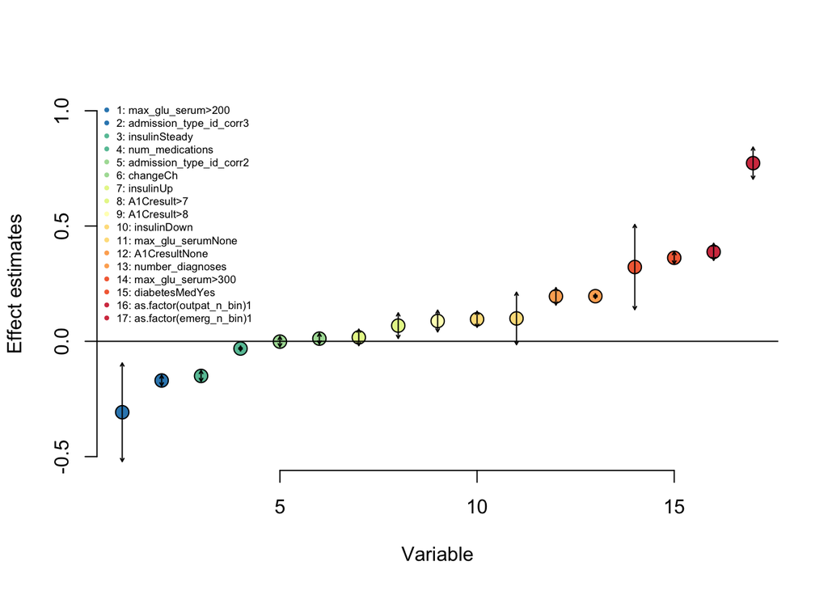

```r
# let's explore the results from the best-fit model

# function to color variables

f <- function(x,n=10, pal, rev = F){
  if(rev == F){
    rev(RColorBrewer::brewer.pal(n, pal))[cut(x,n)]
  }else{
      (RColorBrewer::brewer.pal(n, pal))[cut(x,n)]
    }
}


sum <- data.frame(summary(mod_mix)$coefficients[-1,])

plot(sum$Estimate[order(sum$Estimate)],
     frame = F,
     ylim = c(-0.5,1),
     bg = f(1:length(sum$Estimate), 9, "Spectral"),
     pch = 21,
      ylab = "Effect estimates",
     xlab = "Variable",
     cex = 1.5)
abline(h=0)
arrows(1:length(sum$Estimate),
       sum$Estimate[order(sum$Estimate)]+sum$Std..Error[order(sum$Estimate)],
       1:length(sum$Estimate),



       sum$Estimate[order(sum$Estimate)]-sum$Std..Error[order(sum$Estimate)],
       code = 3, length = 0.03)

legend("topleft",
       pch = 16,
       col = f(1:length(sum$Estimate), 9, "Spectral"),
       bty = "n",
       legend = paste0(1:length(sum$Estimate),":"," ",rownames(sum)[order(sum$Estimate)]),
       cex = 0.55)
```

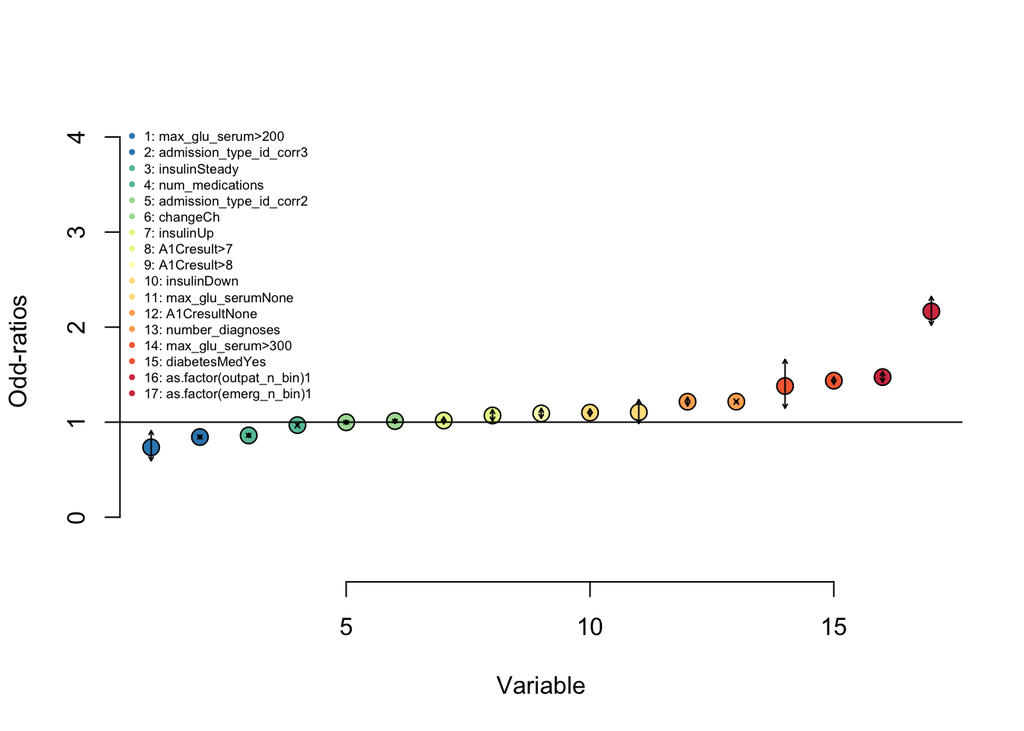

```r
### Make an additional plot to show the odds-ratio

plot(exp(sum$Estimate[order(sum$Estimate)]),
     frame = F,
     ylim = c(-0.5,4),
     bg = f(1:length(sum$Estimate), 9, "Spectral"),
     pch = 21,
      ylab = "Odd-ratios",
     xlab = "Variable",
     cex = 1.5)
abline(h=1)


arrows(1:length(sum$Estimate),
       exp(sum$Estimate[order(sum$Estimate)]+(sum$Std..Error[order(sum$Estimate)])),
       1:length(sum$Estimate),
       exp(sum$Estimate[order(sum$Estimate)]-(sum$Std..Error[order(sum$Estimate)])),
       code = 3, length = 0.03)

legend("topleft",
       pch = 16,
       col = f(1:length(sum$Estimate), 9, "Spectral"),
       bty = "n",
       legend = paste0(1:length(sum$Estimate),":"," ",rownames(sum)[order(sum$Estimate)]),
       cex = 0.55)
```

#### The distribution of random effects

```r
lme4::ranef(mod_mix)
```

```
## $`age:(gender:ethnicity)`
##                                   (Intercept)
## [90-100):Female:AfricanAmerican -0.1857259482
## [90-100):Female:Asian           -0.0325829181
## [90-100):Female:Caucasian        0.0273311025
## [90-100):Female:Hispanic         0.0147778512
## [90-100):Female:Other            0.0281688161
## [90-100):Male:AfricanAmerican    0.0543620128
## [90-100):Male:Asian              0.0387295416
## [90-100):Male:Caucasian         -0.1953096175
## [90-100):Male:Hispanic          -0.0162236148
## [90-100):Male:Other              0.0058607188
## [80-90):Female:AfricanAmerican   0.1727539201
## [80-90):Female:Asian             0.0201728840
## [80-90):Female:Caucasian         0.2435762212
## [80-90):Female:Hispanic         -0.0405196098
## [80-90):Female:Other             0.1278774655
## [80-90):Male:AfricanAmerican     0.1052494254
## [80-90):Male:Asian               0.0569968977
## [80-90):Male:Caucasian           0.1678510383
## [80-90):Male:Hispanic            0.1114148994
## [80-90):Male:Other              -0.1183007186
## [70-80):Female:AfricanAmerican   0.1739318692
## [70-80):Female:Asian             0.0927896472
## [70-80):Female:Caucasian         0.2222474824
## [70-80):Female:Hispanic          0.0671654190
## [70-80):Female:Other             0.0951234125
## [70-80):Male:AfricanAmerican     0.1751924705
## [70-80):Male:Asian               0.0456275360
## [70-80):Male:Caucasian           0.2264086024
## [70-80):Male:Hispanic            0.0132880499
## [70-80):Male:Other               0.0303489318
## [60-70):Female:AfricanAmerican   0.1147167554
## [60-70):Female:Asian            -0.0174183600
## [60-70):Female:Caucasian         0.1319292186
## [60-70):Female:Hispanic          0.0091605678
## [60-70):Female:Other             0.1125640499
## [60-70):Male:AfricanAmerican     0.1003407963
## [60-70):Male:Asian              -0.0500916685
## [60-70):Male:Caucasian           0.0710099903
```

[output cut: 84 more lines]

```
## Male:AfricanAmerican    5.904554e-13
## Male:Asian             -1.618292e-12
## Male:Caucasian         -1.900860e-12
## Male:Hispanic          -2.193413e-13
## Male:Other             -3.080816e-12
##
## $ethnicity
##                 (Intercept)
## AfricanAmerican  0.09735591
## Asian           -0.09842453
## Caucasian        0.10635576
## Hispanic        -0.07594339
## Other           -0.02211326
##
## with conditional variances for "age:(gender:ethnicity)" "time_in_hospital" "gender:ethnicity" "ethnicity"
```